# HOTEL_BOOKING

## 5.14 REQUIRED PARKING SPACES PER CUSTOMER

- It obsevered that people with many cars visits RESORT HOTEL on month :3.
- However visitors with many cars in CITY HOTEL tend to visit the hotel in month :4 and 12.
- In both hotels low car taffic is experienced in month :11 .

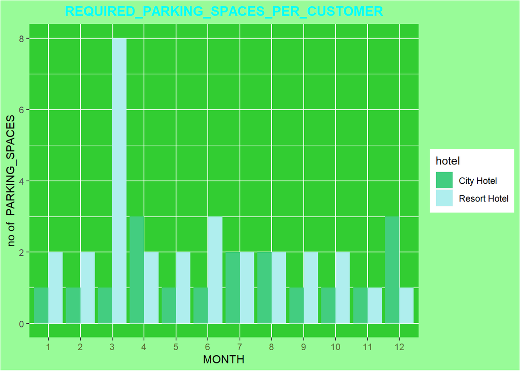

```r
REQUIRED_PARKING_SPACES_PER_CUSTOMER <- HOTEL_BOOKING%>%
   select(required_car_parking_spaces,arrival_date_month,hotel)%>%
   group_by(arrival_date_month,hotel)%>%
   arrange(desc(required_car_parking_spaces))



 #VISUALISATION

 ggplot(REQUIRED_PARKING_SPACES_PER_CUSTOMER ,aes(x=as.factor(arrival_date_month)  ,y=required_car_parking_spaces,fill=hotel))+
   geom_bar(position="dodge",stat = "identity" )+
   scale_fill_manual(values = c("seagreen3","paleturquoise"))+
   labs(title = " REQUIRED_PARKING_SPACES_PER_CUSTOMER ",x="MONTH",y="no of  PARKING_SPACES")+
   theme(plot.title = element_text(hjust = 0.5,colour = "cyan",face = "bold"))+
   theme(panel.background = element_rect(fill = "limegreen"))+
   theme(axis.text.x = element_text(angle = 0,colour = "darkolivegreen"))+
   theme(plot.background = element_rect(fill="palegreen"))
```

# 6 CONCLUSION

- From the above dataset analysis and information therein CITY HOTEL seems the best option.
- However months :1 and 2 are the most cost effective months.
- Other advantages of the CITY HOTEL are :large scale business operations which guarantee quality services ,and social adventure due to its high visitors diversity.

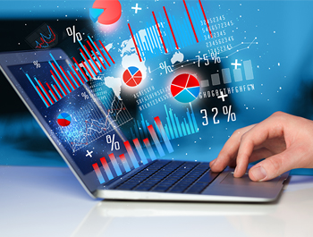

  [**Visit my github account**](https://github.com/eric4820/hotel.git)